# Lukasz Grad Homework 6 - Variable Profiles for COMPAS

We focus on modelling recidivism and violent recidivism as binary classification. Specifically, the positive class denotes whether an individual will commit a crime (a violent crime) within a 2-year period.

## 2. For selected variables from the model (1) calculate Partial Dependence Profiles and Accumulated Local Dependence

```r
plot_pdp <- function(explainer, vars, type = 'partial', groups = NULL) {
    pdp = variable_profile(explainer = explainer, type = type,
                           variables = vars, groups = groups, N = 50)
    plot(pdp, geom = 'profiles')
}

plot_profiles <- function(explainer, vars, groups = NULL) {
    pdp = variable_profile(explainer = explainer, type = 'partial',
                           variables = vars, groups = groups)
    ac = variable_profile(explainer = explainer, type = 'accumulated',
                          variables = vars, groups = groups)
    pdp$agr_profiles$`_label_` = 'Partial Dependence'
    ac$agr_profiles$`_label_` = 'Accumulated Local'
    plot(pdp$agr_profiles, ac$agr_profiles)
}

plot_contrastive <- function(explainer1, explainer2, vars, type = 'partial') {
    p1 = variable_profile(explainer = explainer1, type = type,
                          variables = vars)
    p2 = variable_profile(explainer = explainer2, type = type,
                          variables = vars)
    plot(p1$agr_profiles, p2$agr_profiles)
}
```

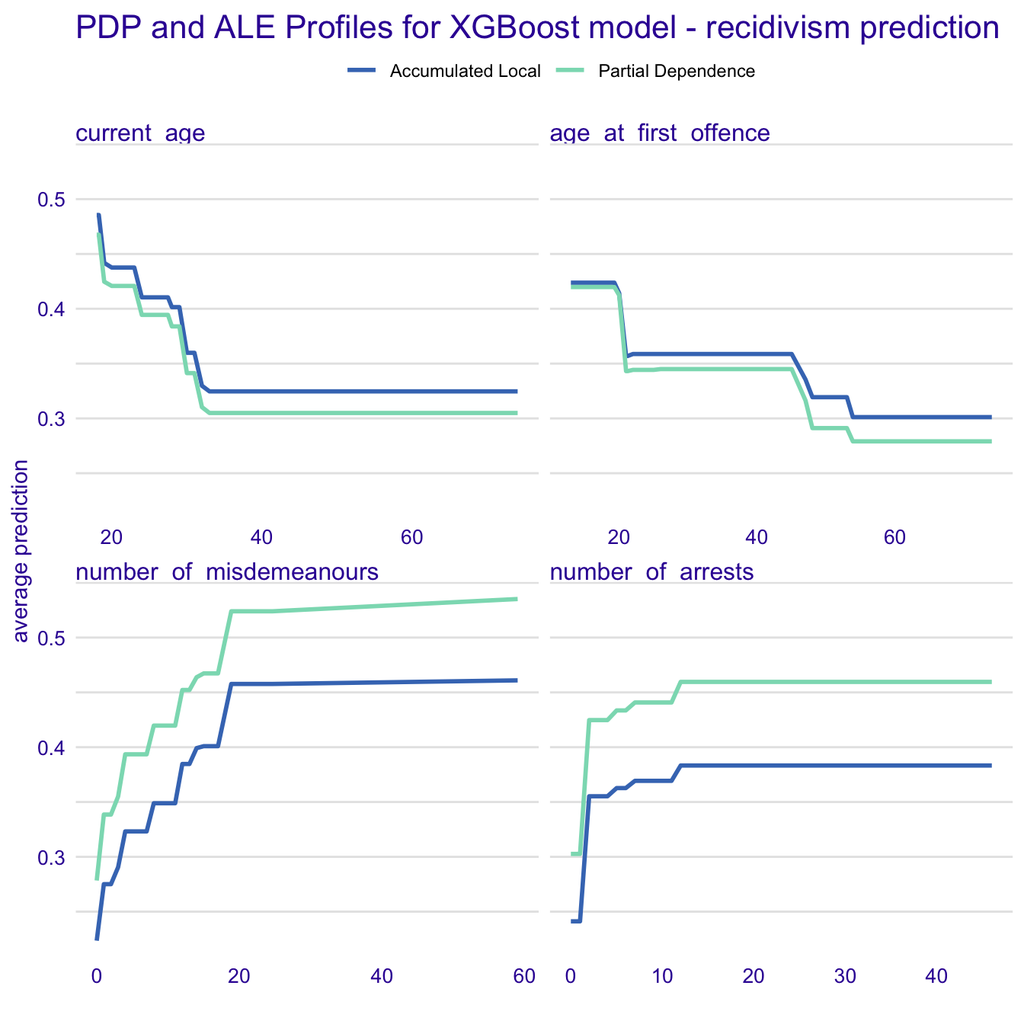

```r
vars = c('current_age',
         'age_at_first_offence',
         'number_of_misdemeanours',
         'number_of_arrests')

plot_profiles(xgb_explain, vars = vars) +
    ggtitle('PDP and ALE Profiles for XGBoost model - recidivism prediction')
```

We present variables profiles for the most impactful variables selected with permutation importance test based on Homework 5.

For the `current_age` and `age_of_first_offence` variables we see the decline in recidivism probability with older age. However, the decline during the young age is steeper for the `current_age` variable. We can also see a clear reduction in predicted probablity around age $20$ for `age_of_first_offence` - suggesting the importance of committing a crime in teen years.

As expected, we see clear correlation of the response with the `number_of_misdeameanours` and `number_of_arrests` predictors. What is interesting is the sharp increase in recidivism probability when the `number_of_arrests` increases from $1$ to $2$. It suggests that people with a single offence are not yet significantly more likely to commit crime again.

We can see little to no difference (up to a constant) in profile shapes for PDP and ALE. Apart from `age_of_first_offence` the profiles are parallel to each other, suggesting the effect of variables on the response has little to no dependence on the values of other variables.

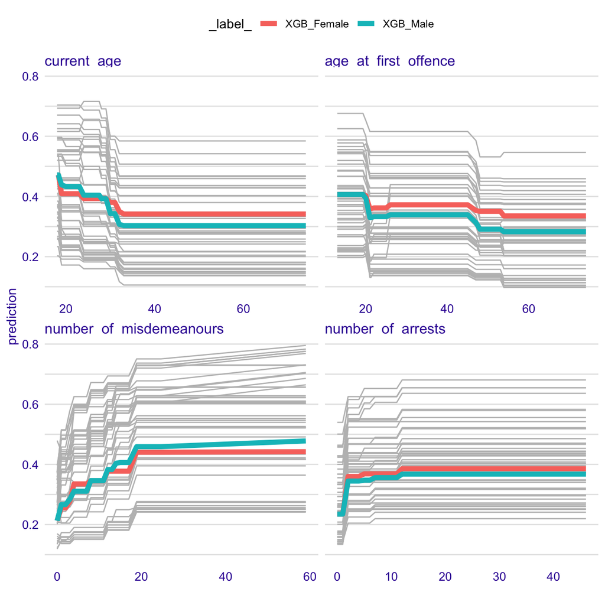

```r
plot_pdp(xgb_explain, vars = vars, type = 'accumulated', groups = 'sex')
```

## 3. Train a second model with a different structure (neural nets, linear, other boosting) and find a variable that has different behaviour between models

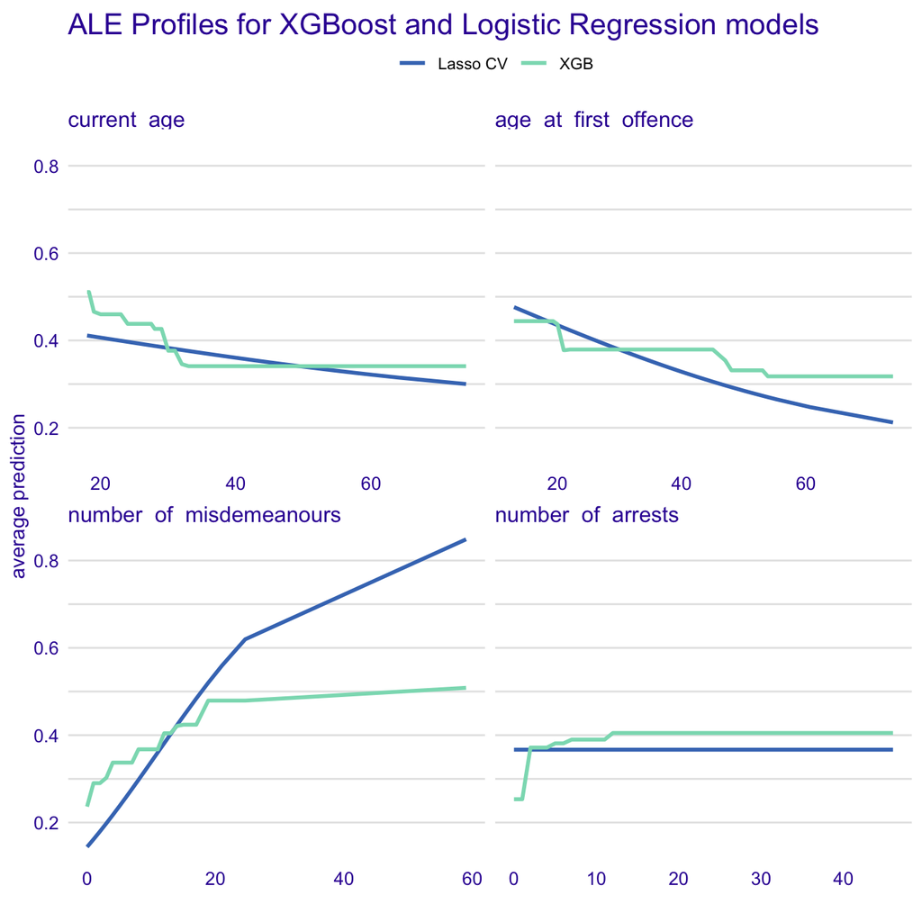

```r
plot_contrastive(cv_glmnet_explain, xgb_explain, vars, type = 'accumulated') +
    ggtitle('ALE Profiles for XGBoost and Logistic Regression models')
```

We can see similar monotonic profiles for the age variables. As expected, the linear model profiles are smooth while we observe sharp declines for the boosted trees model. Overall, we see that for Logistic Regression model the impact of `current_age` is lower than for XGBoost. On the other hand, impact of `age_of_first_offence` is higher.

The biggest difference in model profiles is observed for `number_of_arrests` variable. In case of the XGBoost model we see a clear increase in the response when the number of arrests increases from $1$ to $2$. However, the profile for linear model is basically flat which indicates that the Logistic Lasso model did not chose this predictor as significant at all.